# Exploring Data - Ch2

# **VERİ KEŞFİ** (Exploring data)

**This chapter covers**

 Using summary statistics to explore data

 Exploring data using visualization

 Finding problems and issues during data exploration

```r
custdata1 <- read.table("https://github.com/scizmeli/datascience_class_helper_files/raw/master/custdata.tsv",header=T,sep='\t') #control
```

```r
custdata <- read.table('https://github.com/scizmeli/datascience_class_helper_files/raw/master/custdata1.tsv',header=T,sep=',')
```

```r
head(custdata1)
```

|  | custid | sex | is.employed | income | marital.stat | health.ins | housing.type | recent.move | num.vehicles | age | state.of.res |
| --- | --- | --- | --- | --- | --- | --- | --- | --- | --- | --- | --- |
| 1 | 2068 | F | NA | 11300 | Married | TRUE | Homeowner free and clear | FALSE | 2 | 49 | Michigan |
| 2 | 2073 | F | NA | 0 | Married | TRUE | Rented | TRUE | 3 | 40 | Florida |
| 3 | 2848 | M | TRUE | 4500 | Never Married | FALSE | Rented | TRUE | 3 | 22 | Georgia |
| 4 | 5641 | M | TRUE | 20000 | Never Married | FALSE | Occupied with no rent | FALSE | 0 | 22 | New Mexico |
| 5 | 6369 | F | TRUE | 12000 | Never Married | TRUE | Rented | TRUE | 1 | 31 | Florida |
| 6 | 8322 | F | TRUE | 180000 | Never Married | TRUE | Homeowner with mortgage/loan | FALSE | 1 | 40 | New York |

```r
knitr::kable(head(custdata1))
```

| custid | sex | is.employed | income | marital.stat | health.ins | housing.type | recent.move | num.vehicles | age | state.of.res |
| --- | --- | --- | --- | --- | --- | --- | --- | --- | --- | --- |
| 2068 | F | NA | 11300 | Married | TRUE | Homeowner free and clear | FALSE | 2 | 49 | Michigan |
| 2073 | F | NA | 0 | Married | TRUE | Rented | TRUE | 3 | 40 | Florida |
| 2848 | M | TRUE | 4500 | Never Married | FALSE | Rented | TRUE | 3 | 22 | Georgia |
| 5641 | M | TRUE | 20000 | Never Married | FALSE | Occupied with no rent | FALSE | 0 | 22 | New Mexico |
| 6369 | F | TRUE | 12000 | Never Married | TRUE | Rented | TRUE | 1 | 31 | Florida |
| 8322 | F | TRUE | 180000 | Never Married | TRUE | Homeowner with mortgage/loan | FALSE | 1 | 40 | New York |

```r
summary(custdata1)
```

```
##      custid        sex     is.employed         income
##  Min.   :   2068   F:440   Mode :logical   Min.   : -8700
##  1st Qu.: 345667   M:560   FALSE:73        1st Qu.: 14600
##  Median : 693403           TRUE :599       Median : 35000
##  Mean   : 698500           NA's :328       Mean   : 53505
##  3rd Qu.:1044606                           3rd Qu.: 67000
##  Max.   :1414286                           Max.   :615000
##
##              marital.stat health.ins
##  Divorced/Separated:155   Mode :logical
##  Married           :516   FALSE:159
##  Never Married     :233   TRUE :841
##  Widowed           : 96
##
##
##
##                        housing.type recent.move      num.vehicles
##  Homeowner free and clear    :157   Mode :logical   Min.   :0.000
##  Homeowner with mortgage/loan:412   FALSE:820       1st Qu.:1.000
##  Occupied with no rent       : 11   TRUE :124       Median :2.000
##  Rented                      :364   NA's :56        Mean   :1.916
##  NA's                        : 56                   3rd Qu.:2.000
##                                                     Max.   :6.000
##                                                     NA's   :56
##       age              state.of.res
##  Min.   :  0.0   California  :100
##  1st Qu.: 38.0   New York    : 71
##  Median : 50.0   Pennsylvania: 70
##  Mean   : 51.7   Texas       : 56
##  3rd Qu.: 64.0   Michigan    : 52
##  Max.   :146.7   Ohio        : 51
##                  (Other)     :600
```

```r
summary(custdata$income)
```

```
##    Min. 1st Qu.  Median    Mean 3rd Qu.    Max.
##   -8700   14600   35000   53505   67000  615000
```

Spotting problems using graphics and visualization  A graphic should display as much information as it can, with the lowest possible cognitive strain to the viewer.

 Strive for clarity. Make the data stand out. Specific tips for increasing clarity include

– Avoid too many superimposed elements, such as too many curves in the same graphing space.

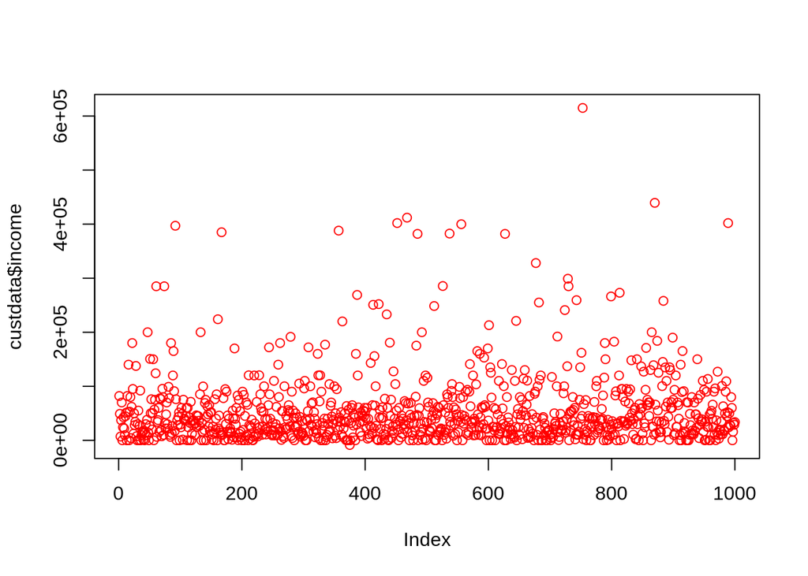

```r
plot(custdata$income, col = "red")
```

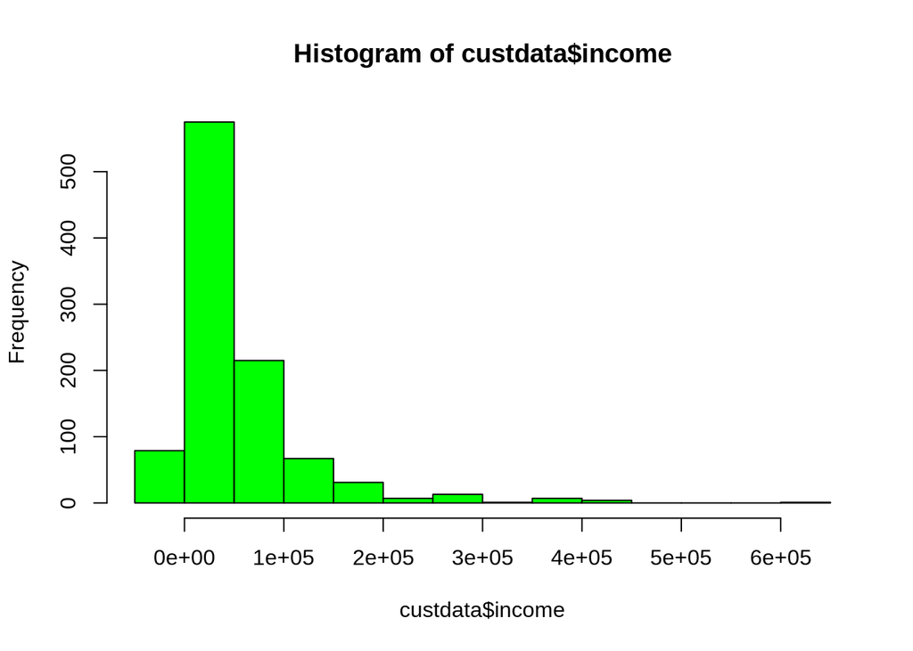

```r
hist(custdata$income, col = "green")
```

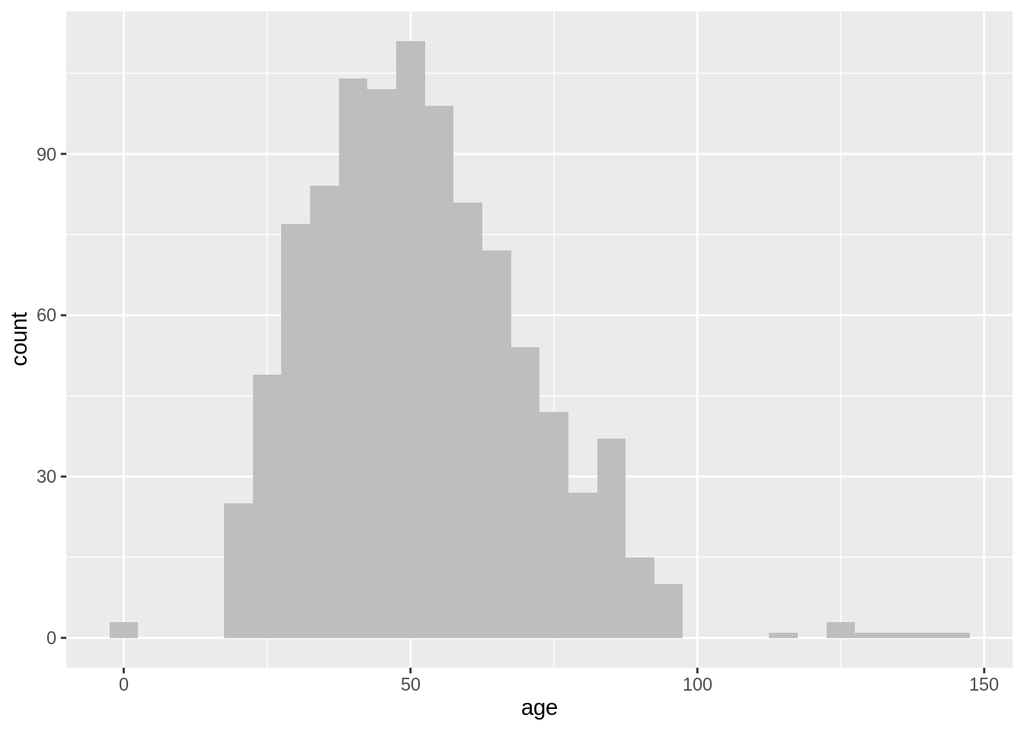

```r
library(ggplot2)
ggplot(custdata) +
geom_histogram(aes(x=age),
binwidth=5, fill="gray")
```

A histogram tells you where your data is concentrated. It also visually highlights outliers and anomalies.

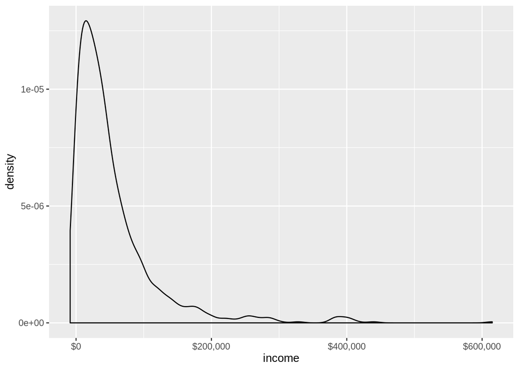

```r
#library(ggplot)
library(scales)
ggplot(custdata) + geom_density(aes(x=income)) +
scale_x_continuous(labels=dollar)
```

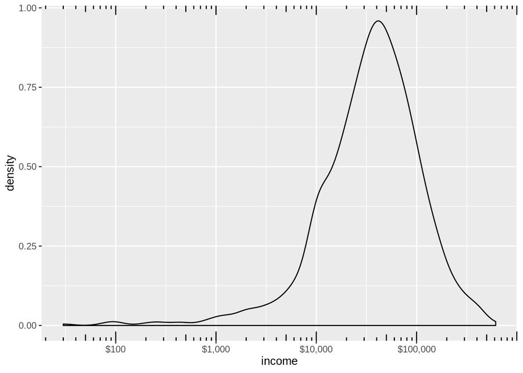

```r
ggplot(custdata)+
geom_density(aes(x=income))+
scale_x_log10(breaks=c(100,1000,10000,100000), labels=dollar)+
annotation_logticks(sides="bt")
```

```r
Income <- custdata$income/100
```

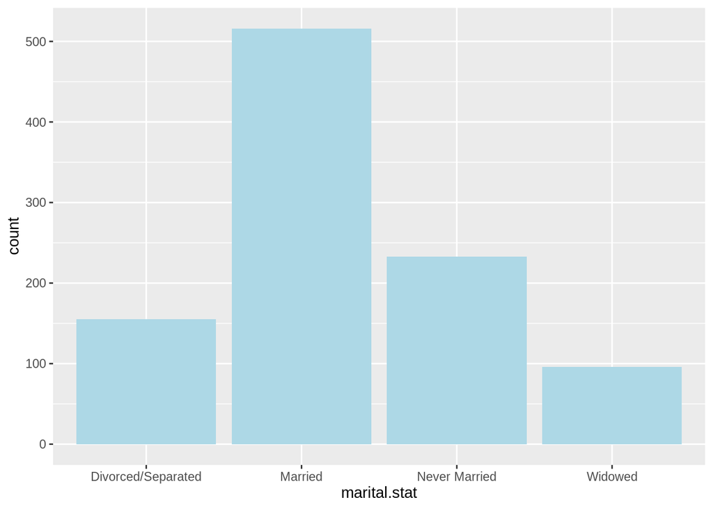

```r
ggplot(custdata) + geom_bar(aes(x=marital.stat), fill="lightblue")
```

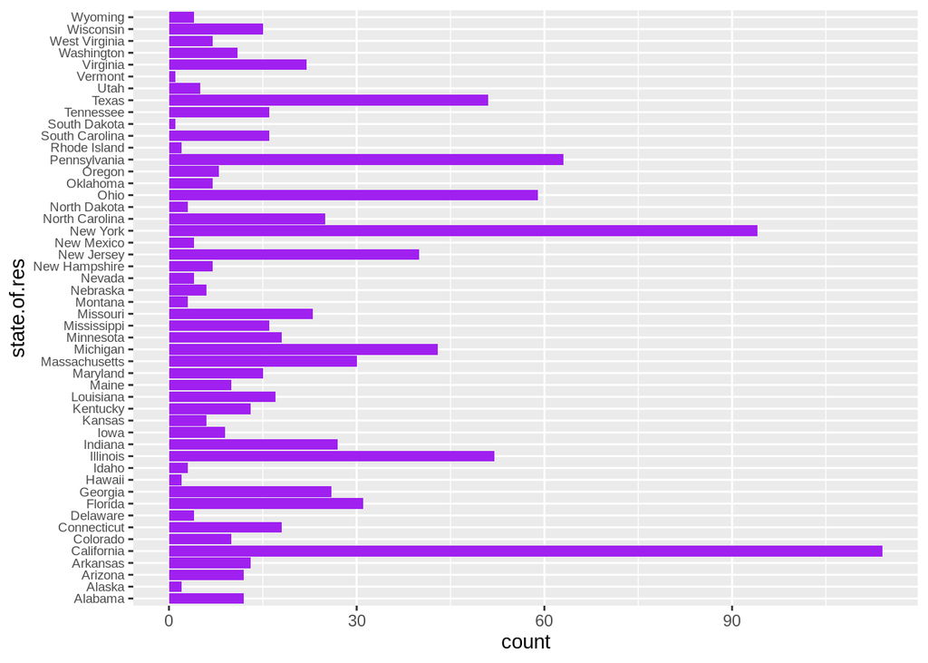

```r
ggplot(custdata) +
geom_bar(aes(x=state.of.res),
fill="purple") +
coord_flip() +
theme(axis.text.y=element_text(size=rel(0.8)))
```

Producing a bar chart with sorted categories

```r
statesums <- table(custdata$state.of.res)
statef <- as.data.frame(statesums)
colnames(statef)<-c("state.of.res", "count")
summary(statef)
```

```
##      state.of.res     count
##  Alabama   : 1    Min.   :  1.00
##  Alaska    : 1    1st Qu.:  5.25
##  Arizona   : 1    Median : 12.50
##  Arkansas  : 1    Mean   : 20.00
##  California: 1    3rd Qu.: 24.50
##  Colorado  : 1    Max.   :114.00
##  (Other)   :44
```

```r
statef <- transform(statef,state.of.res=reorder(state.of.res, count))
summary(statef)
```

```
##        state.of.res     count
##  South Dakota: 1    Min.   :  1.00
##  Vermont     : 1    1st Qu.:  5.25
##  Alaska      : 1    Median : 12.50
##  Hawaii      : 1    Mean   : 20.00
##  Rhode Island: 1    3rd Qu.: 24.50
##  Idaho       : 1    Max.   :114.00
##  (Other)     :44
```

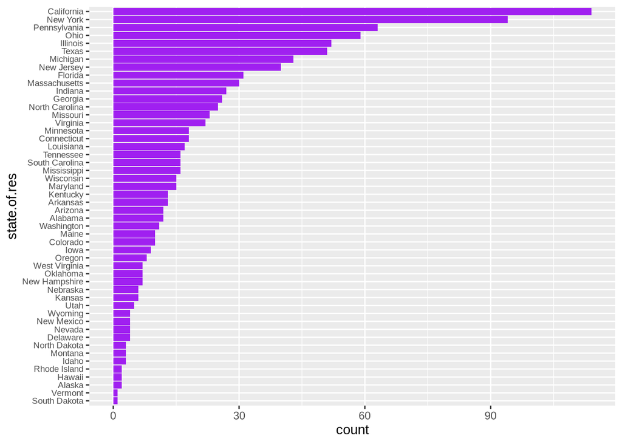

```r
ggplot(statef)+ geom_bar(aes(x=state.of.res,y=count),
stat="identity",
fill="purple") +
coord_flip() +
theme(axis.text.y=element_text(size=rel(0.8)))
```

Producing a line plot

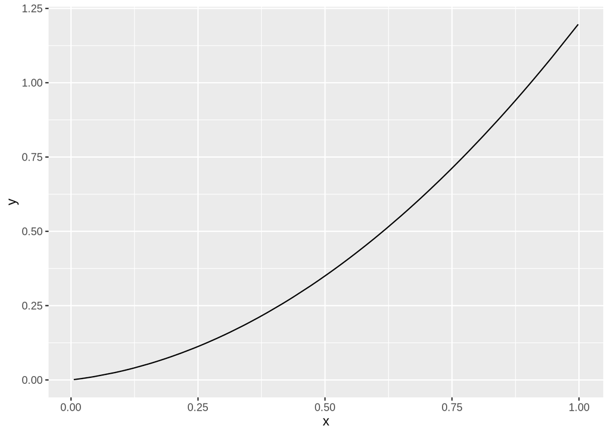

```r
x <- runif(100)
y <- x^2 + 0.2*x
ggplot(data.frame(x=x,y=y), aes(x=x,y=y)) + geom_line()
```

Examining the correlation between age and income

```r
custdata2 <- subset(custdata,(custdata$age > 0 & custdata$age < 100 & custdata$income > 0))
cor(custdata2$age, custdata2$income)
```

```
## [1] -0.02240845
```

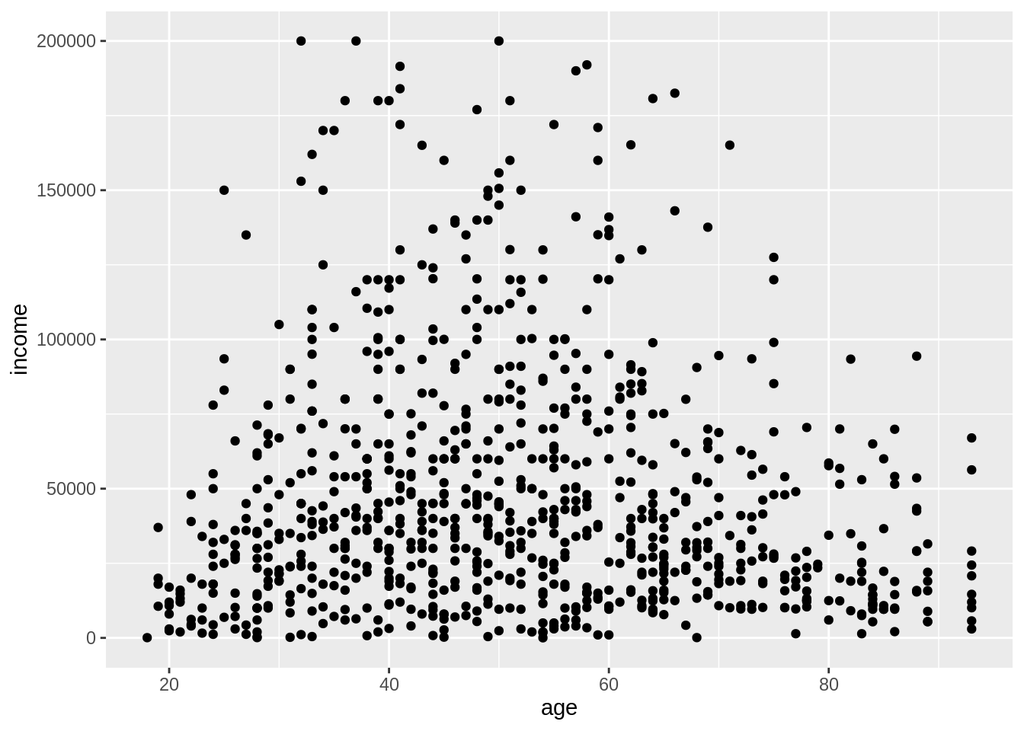

```r
ggplot(custdata2, aes(x=age, y=income)) +
geom_point() + ylim(0, 200000)
```

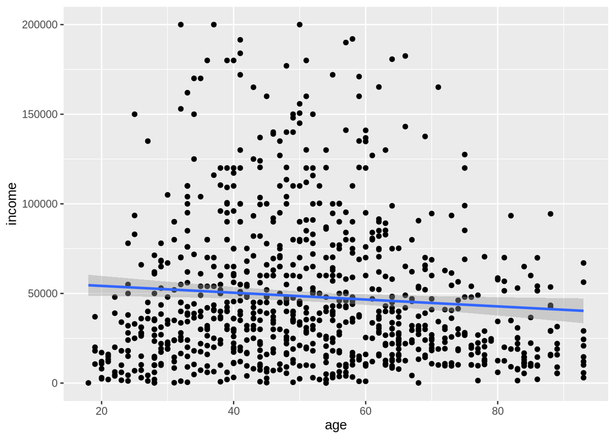

```r
ggplot(custdata2, aes(x=age, y=income)) + geom_point() + stat_smooth(method="lm") +
ylim(0, 200000)
```

In this case, the linear fit doesn’t really capture the shape of the data. You can better capture the shape by instead plotting a smoothing curve through the data

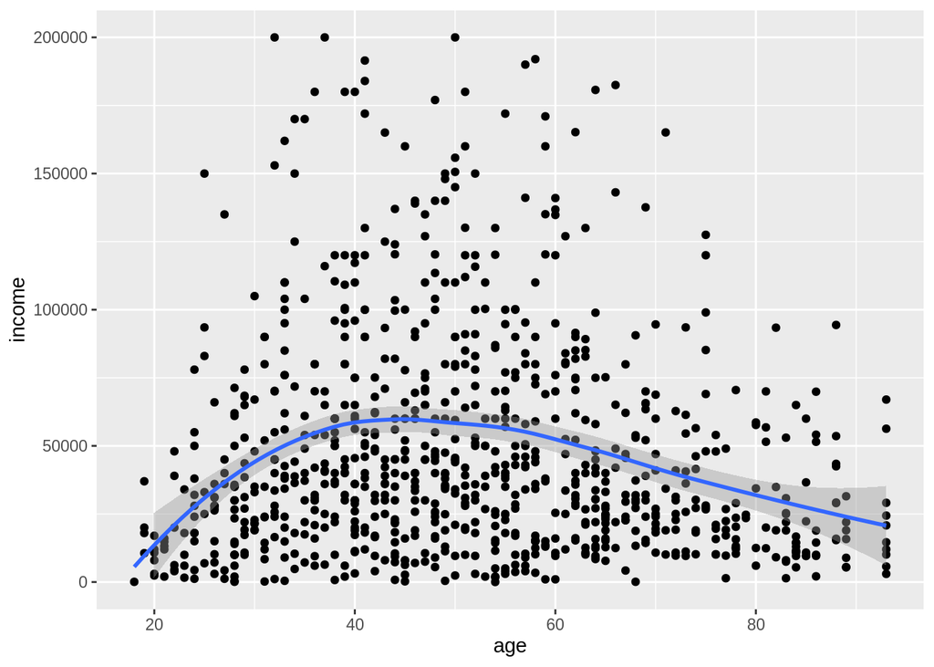

```r
ggplot(custdata2, aes(x=age, y=income)) + geom_point() + geom_smooth() +
ylim(0, 200000)
```

Plotting the distribution of health.ins as a function of age

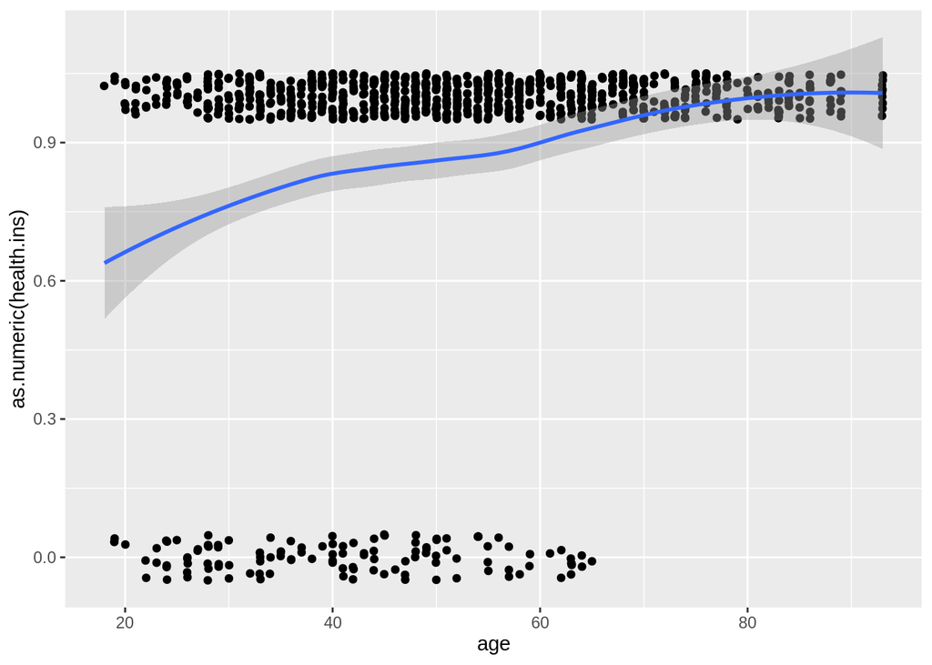

```r
ggplot(custdata2, aes(x=age, y=as.numeric(health.ins))) +geom_point(position=position_jitter(w=0.05, h=0.05)) +
geom_smooth()
```

**HEXBIN PLOTS** A hexbin plot is like a two-dimensional histogram. The data is divided into bins, and the number of data points in each bin is represented by color or shading. Let’s go back to the income versus age example.

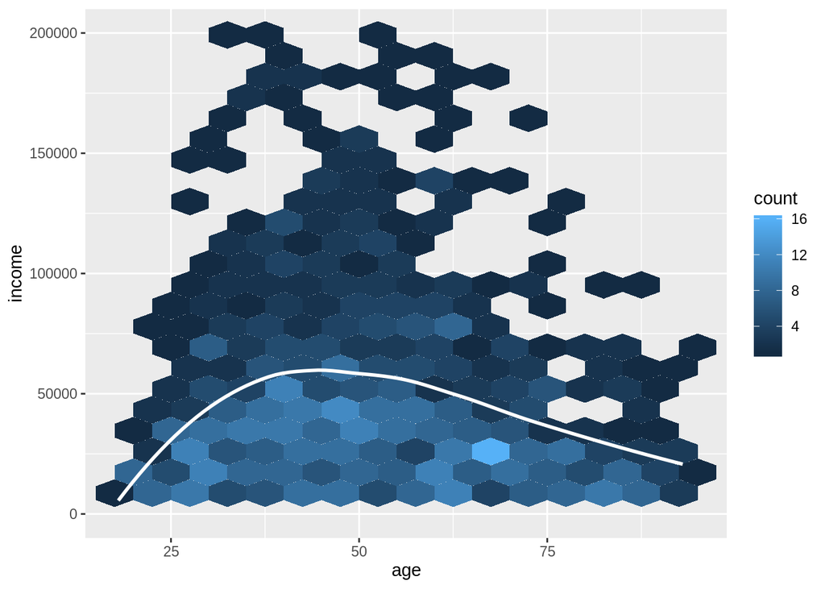

```r
#install.packages("hexbin")
library(hexbin)
ggplot(custdata2, aes(x=age, y=income)) + geom_hex(binwidth=c(5, 10000)) +
geom_smooth(color="white", se=F) +
ylim(0,200000)
```

**BAR CHARTS FOR TWO CATEGORICAL VARIABLES**

Let’s examine the relationship between marital status and the probability of health insurance coverage. The most straightforward way to visualize this is with a stacked bar chart, as shown in figure 3.15.

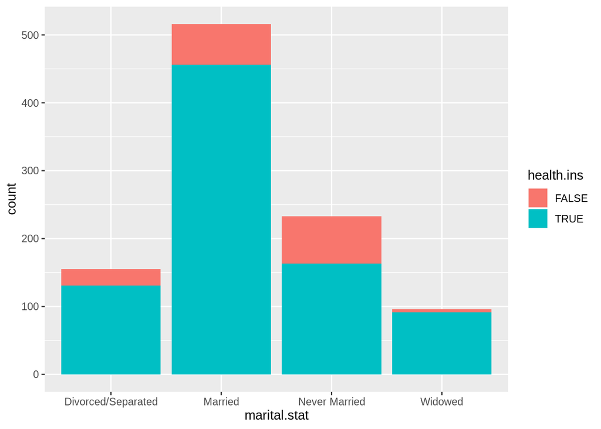

```r
ggplot(custdata) + geom_bar(aes(x=marital.stat,
fill=health.ins))
```

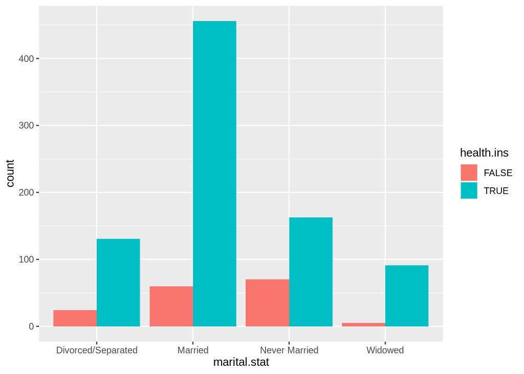

```r
ggplot(custdata) + geom_bar(aes(x=marital.stat,
fill=health.ins),
position="dodge")
```

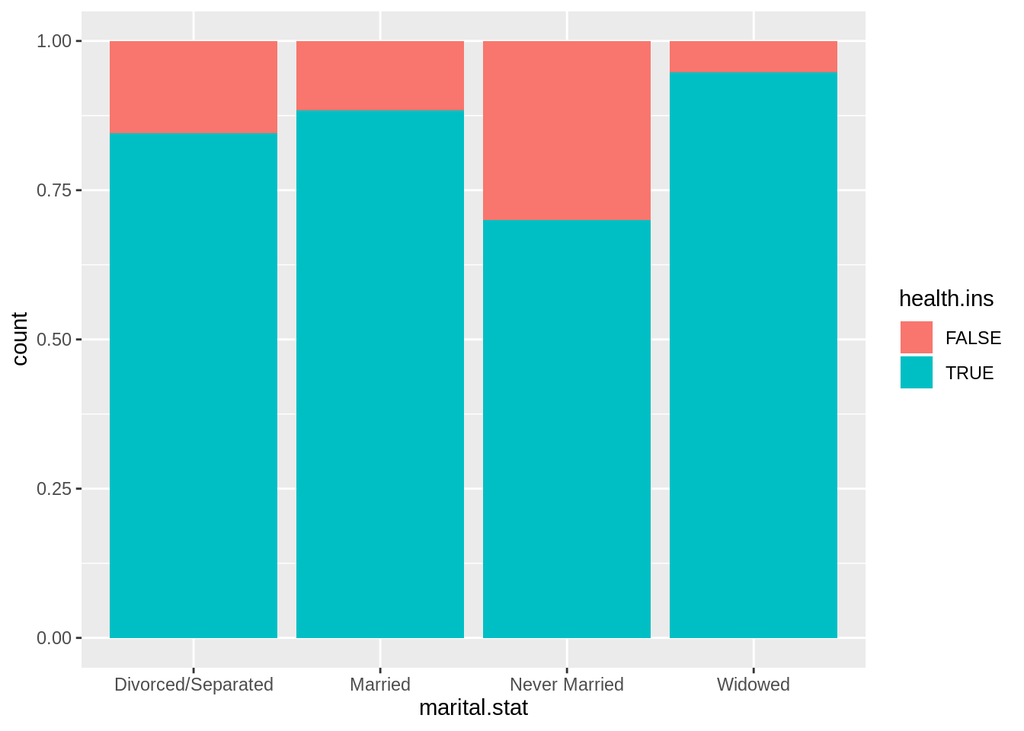

```r
ggplot(custdata) + geom_bar(aes(x=marital.stat,
fill=health.ins),
position="fill")
```

Plotting data with a rug

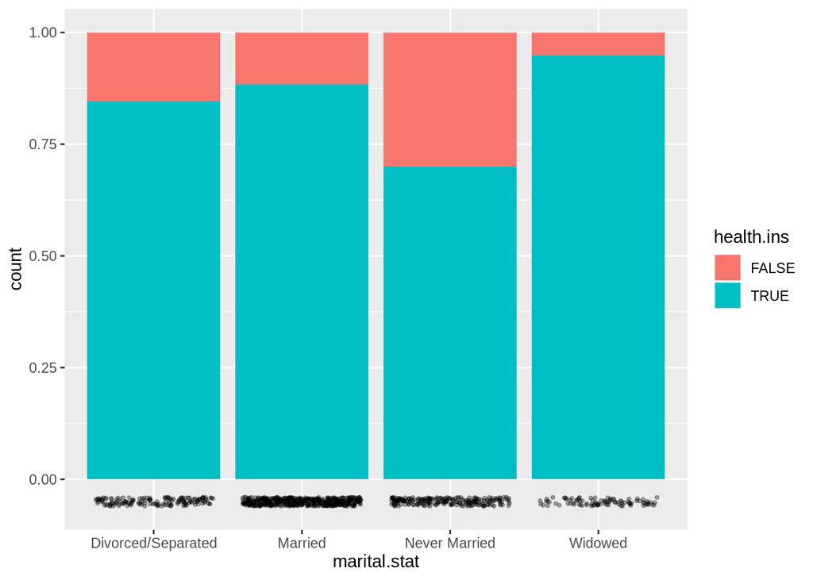

```r
ggplot(custdata, aes(x=marital.stat)) +
geom_bar(aes(fill=health.ins), position="fill") +
geom_point(aes(y=-0.05), size=0.75, alpha=0.3,
position=position_jitter(h=0.01))
```

Plotting a bar chart with and without facets

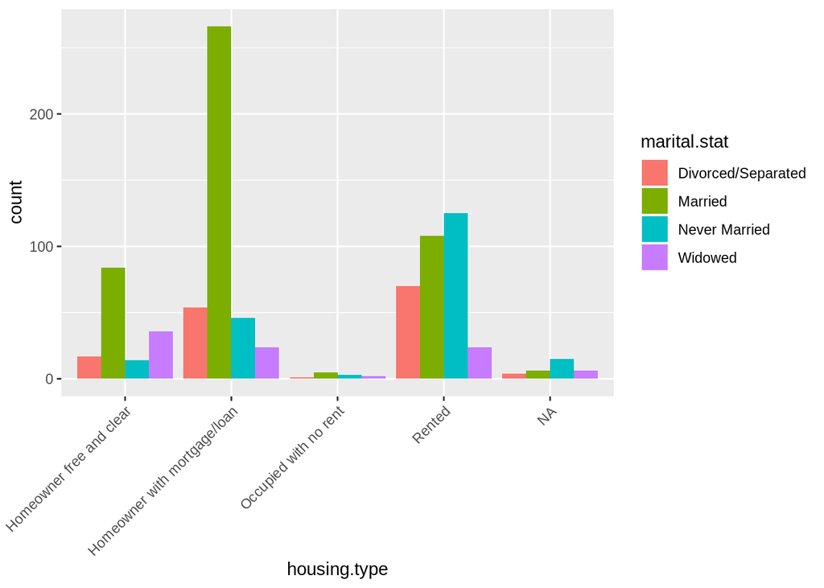

```r
ggplot(custdata2) +
geom_bar(aes(x=housing.type, fill=marital.stat ),
position="dodge") +
theme(axis.text.x = element_text(angle = 45, hjust = 1))
```

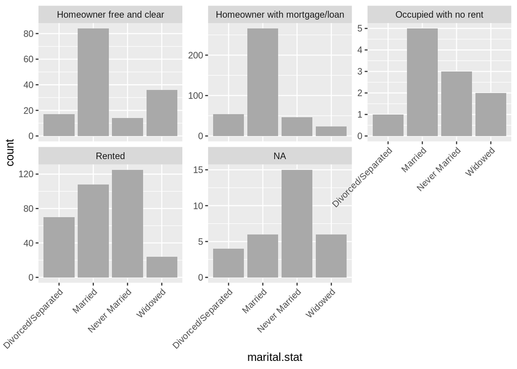

```r
ggplot(custdata2) +
geom_bar(aes(x=marital.stat), position="dodge",
fill="darkgray") +
facet_wrap(~housing.type, scales="free_y") +
theme(axis.text.x = element_text(angle = 45, hjust = 1))
```

**EXTRA**

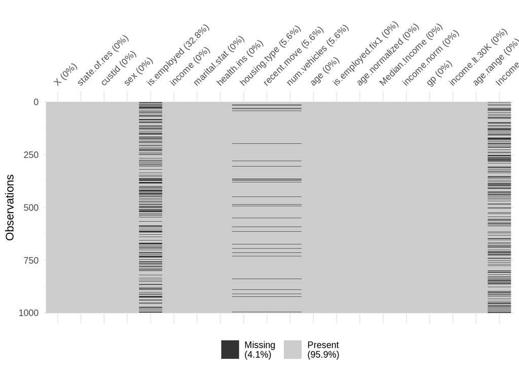

```r
library(naniar)
vis_miss(custdata)
```

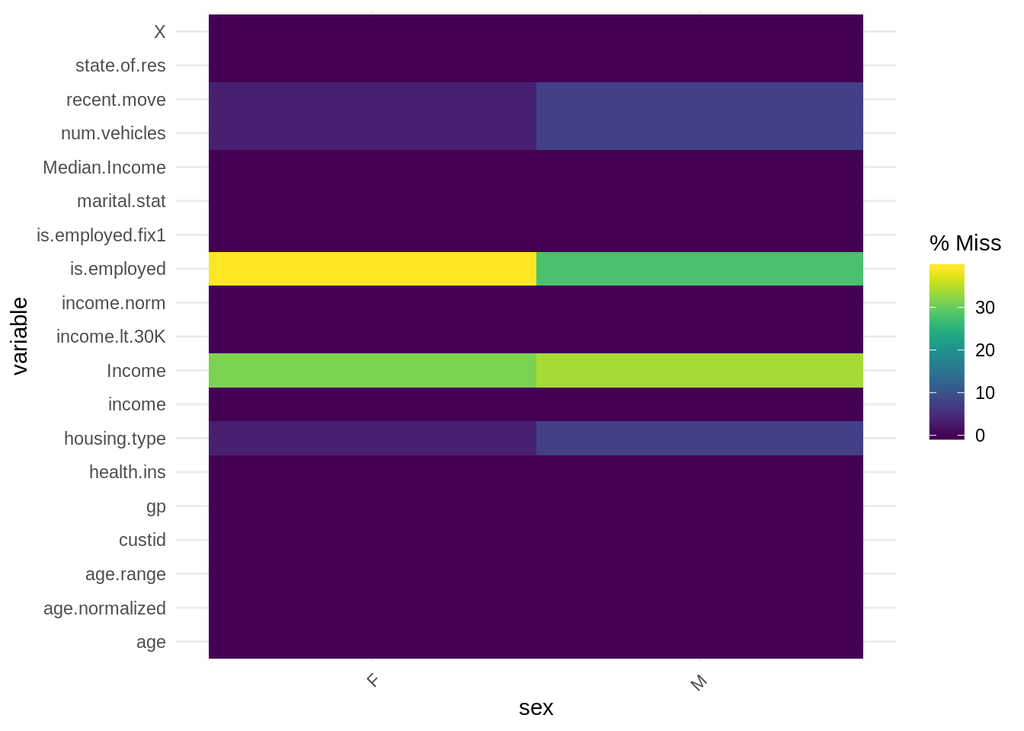

```r
gg_miss_fct(x = custdata, fct = sex)
```

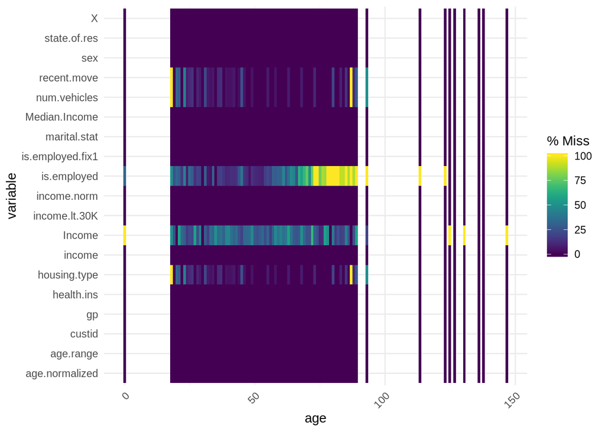

```r
gg_miss_fct(x = custdata, fct = age)
```

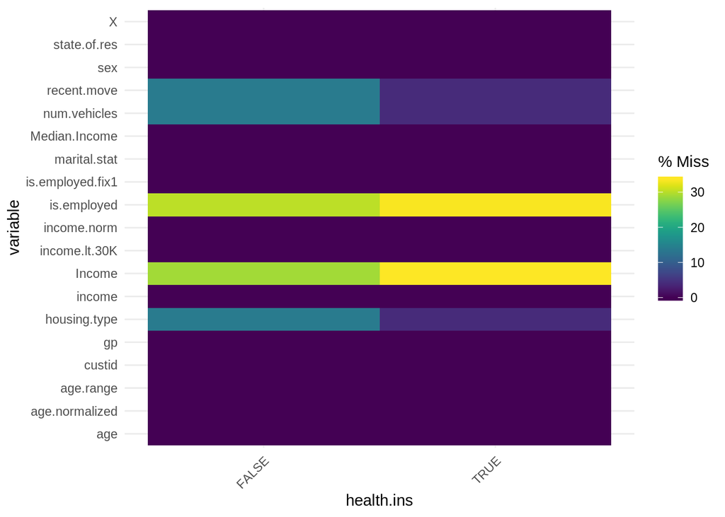

```r
gg_miss_fct(x = custdata, fct = health.ins)
```

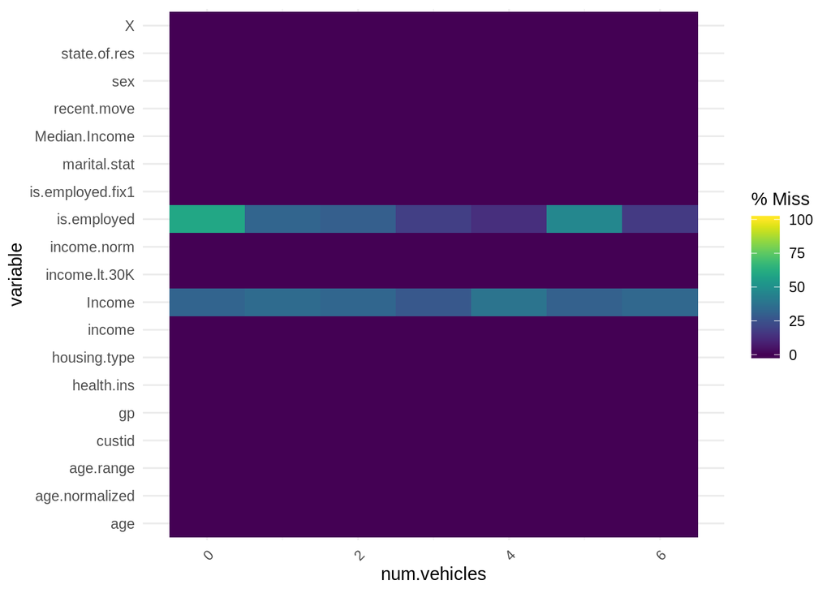

```r
gg_miss_fct(x = custdata, fct = num.vehicles)
```